# tissue_simulator: an end-to-end tour

3D simulated biological tissue sections with network-based spatial analysis and ABM-initialization workflows.

[Docs](https://emcramer.github.io/tissue_simulator/) · [Source](https://github.com/emcramer/tissue_simulator) · [Wiki](https://github.com/emcramer/tissue_simulator/wiki)

## What it does

- **Pack** 3D tissues with random sphere placement (`TissueSection` + `SpherePacker`).
- **Slice** them at arbitrary planes (`TissueSlicer`).
- **Build spatial networks** and compute interaction statistics (`SpatialNetworkAnalyzer`).
- **Generate replicates** matching a target's contact statistics (`ReplicateGenerator`).
- **Assign cell types** by simulated annealing to match an adjacency target (`GraphColorizer`).
- **Reproducibility** — every stochastic component takes a `seed=`.
- **MCP server** exposes the API to LLMs (Claude Desktop / agents).

## Install

```
pip install -e ".[mcp]"
```

Optional extras: `.[docs]` for the docs site, `.[dev]` for tests.

## Create a tissue

A few lines packs a 3D tissue. `seed=2026` makes it reproducible.

```
Placed 282 cells; packing fraction = 0.38
```

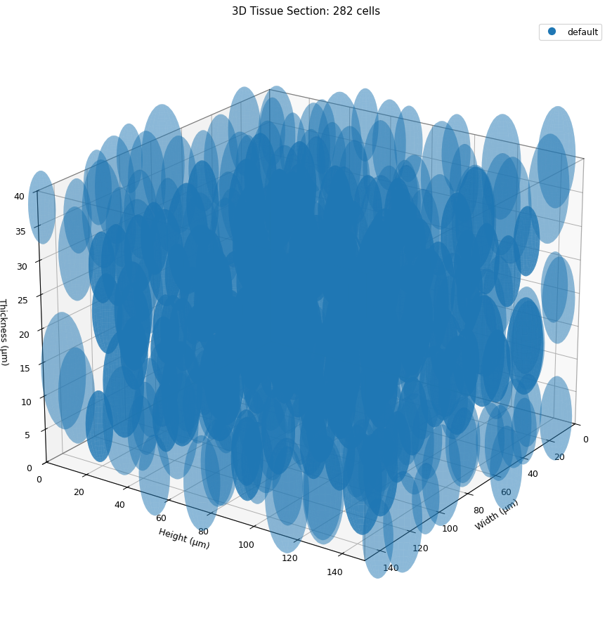

```python
from tissue_simulator import TissueSection

tissue = TissueSection(height=150, width=150, thickness=40, cell_radii=(5, 9), seed=2026)
n = tissue.generate_cells(max_attempts=500)
print(f"Placed {n} cells; packing fraction = {tissue.get_cell_statistics()['packing_fraction']:.2f}")
tissue.visualize(elevation=22, azimuth=35)
fit_slide()
plt.show()
```

## Multi-type tissues

Pass a dict of `(min, max)` radii per type. Cells are color-coded.

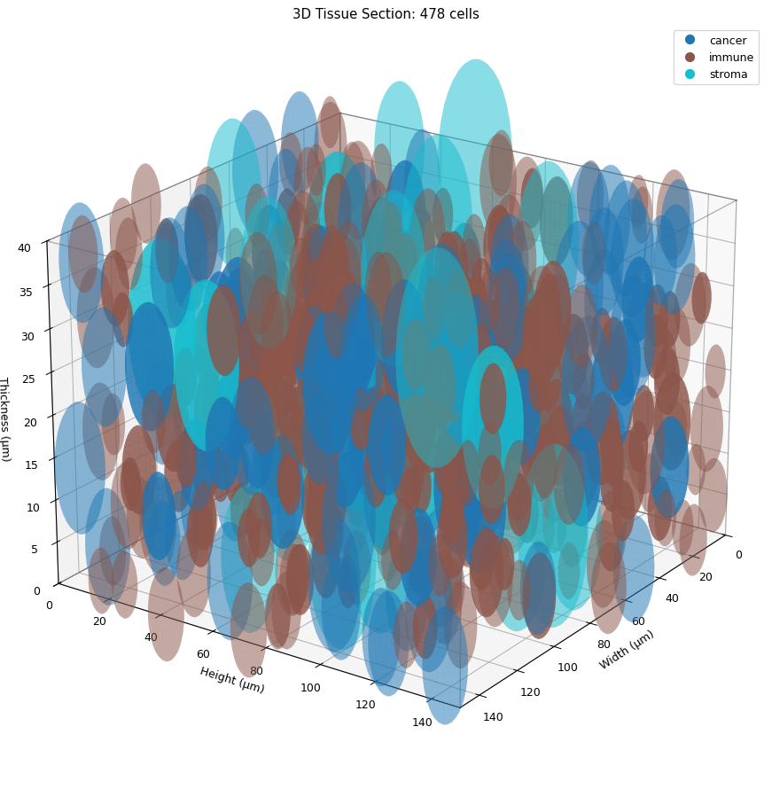

```python
multi = TissueSection(
    height=150, width=150, thickness=40,
    cell_radii={"cancer": (5, 8), "immune": (3, 6), "stroma": (8, 12)},
    seed=2026,
)
multi.generate_cells(max_attempts=500)
multi.visualize(elevation=22, azimuth=35)
fit_slide()
plt.show()
```

## Slice it (2D)

`TissueSlicer` extracts a planar cross-section. Cell radii project to circles.

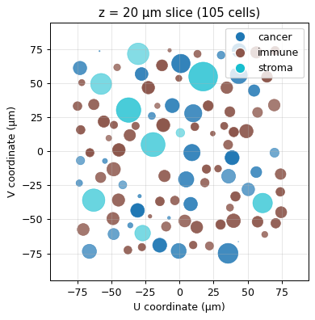

```python
from tissue_simulator import TissueSlicer

slicer = TissueSlicer(multi)
slicer.slice_plane(z_position=20)
slicer.visualize_slice_2d(
    title=f"z = 20 μm slice ({len(slicer.slice_cells)} cells)",
    figsize=SLIDE_FIGSIZE,
)
plt.show()
```

## Slice in 3D context

Same slice, shown against the parent tissue.

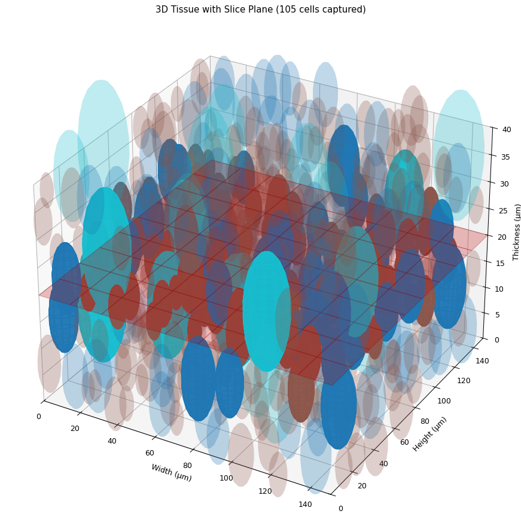

```python
slicer.visualize_slice_in_3d(plane_alpha=0.25)
fit_slide()
plt.show()
```

## Build a spatial network

Connect cells whose centers are within a radius — here 18 μm.

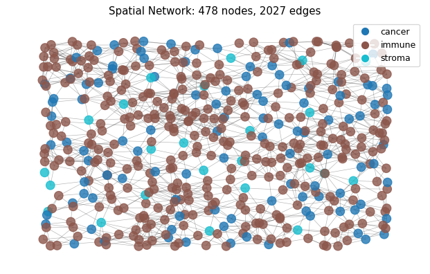

```python
from tissue_simulator import SpatialNetworkAnalyzer

analyzer = SpatialNetworkAnalyzer()
analyzer.build_network_from_tissue(multi, mode="radius", radius=18.0)
analyzer.visualize_network(layout="spatial", figsize=SLIDE_FIGSIZE)
plt.show()
```

## Per-type interaction statistics

How many edges of each cross-type pair? Normalised by the maximum possible.

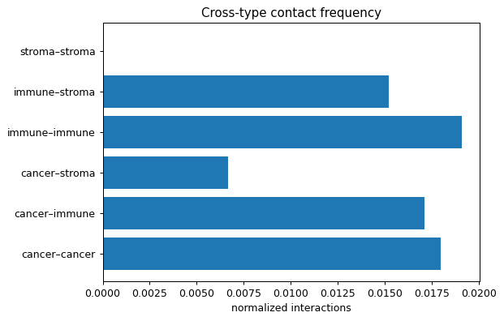

```python
import numpy as np

stats = analyzer.compute_interaction_statistics()
labels = [f"{s.type_a}–{s.type_b}" for s in stats]
vals = [s.normalized_interactions for s in stats]
fig, ax = plt.subplots(figsize=SLIDE_FIGSIZE)
ax.barh(labels, vals)
ax.set_xlabel("normalized interactions")
ax.set_title("Cross-type contact frequency")
fig.tight_layout()
plt.show()
```

## Generate replicates

`ReplicateGenerator` repacks new positions that match the target's contact statistics and proportions. Same `seed=` → same replicates.

```
Generating replicate 1/2...
```

```
  Cells: 455, Divergence: 0.1084
Generating replicate 2/2...
```

```
  Cells: 392, Divergence: 0.1065
Generated 2 replicates, 455 and 392 cells respectively.
```

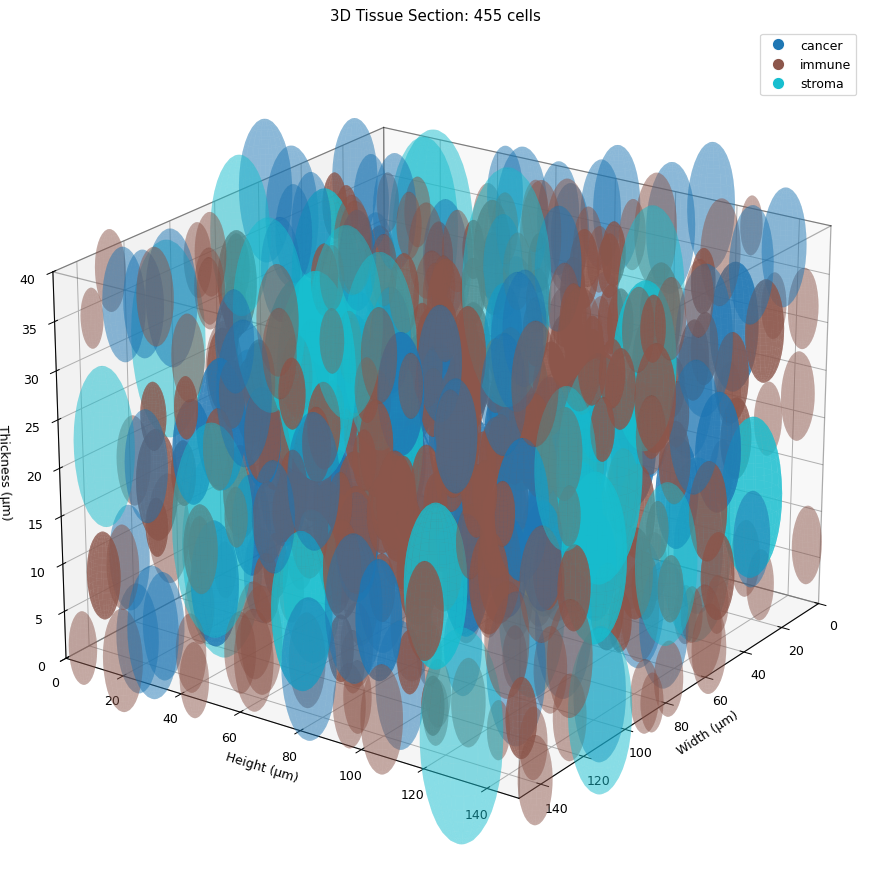

```python
from tissue_simulator import ReplicateGenerator, load_target_statistics_from_tissue

target_stats = load_target_statistics_from_tissue(multi, network_mode="radius", network_radius=18.0)
gen = ReplicateGenerator(
    target_stats=target_stats,
    tissue_dimensions=(150, 150, 40),
    base_cell_radii={"cancer": (5, 8), "immune": (3, 6), "stroma": (8, 12)},
    network_mode="radius",
    network_radius=18.0,
    seed=42,
)
replicates = gen.generate_replicates(num_replicates=2, max_attempts=300, max_iterations=2, tolerance=0.25)
print(f"Generated {len(replicates)} replicates, "
      f"{len(replicates[0][0].cells)} and {len(replicates[1][0].cells)} cells respectively.")
replicates[0][0].visualize(elevation=22, azimuth=35)
fit_slide()
plt.show()
```

## Cell-type assignment via simulated annealing

`GraphColorizer` matches a target adjacency structure on a fixed graph. Seeded for reproducibility.

```
Using provided target statistics...
Target Statistics: {'node_counts': {'cancer': 14, 'immune': 14, 'stroma': 12}, 'edge_counts': {'cancer-cancer': 12, 'cancer-immune': 14, 'cancer-stroma': 10, 'immune-immune': 12, 'immune-stroma': 10, 'stroma-stroma': 8}, 'neighbor_dist': {'cancer': {'cancer': 1.5, 'immune': 1.3, 'stroma': 1.0}, 'imm…
```

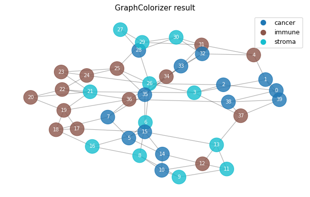

```python
import networkx as nx
from tissue_simulator import GraphColorizer
from tissue_simulator.graph_coloring import visualize_colored_graph

# Small synthetic graph for the demo — quick and visually clean.
G = nx.connected_watts_strogatz_graph(40, 4, 0.2, seed=7)
target = {
    "node_counts": {"cancer": 14, "immune": 14, "stroma": 12},
    "edge_counts": {"cancer-cancer": 12, "cancer-immune": 14, "cancer-stroma": 10,
                    "immune-immune": 12, "immune-stroma": 10, "stroma-stroma": 8},
    "neighbor_dist": {
        "cancer": {"cancer": 1.5, "immune": 1.3, "stroma": 1.0},
        "immune": {"cancer": 1.3, "immune": 1.5, "stroma": 1.0},
        "stroma": {"cancer": 1.0, "immune": 1.0, "stroma": 1.4},
    },
}
colorizer = GraphColorizer(target_graph=G, colors=["cancer", "immune", "stroma"],
                            target_statistics=target, seed=42)
assignment = colorizer.colorize(initial_temp=10.0, final_temp=0.5,
                                 cooling_rate=0.95, max_iterations=200, verbose=False)
visualize_colored_graph(G, assignment, title="GraphColorizer result", figsize=SLIDE_FIGSIZE)
plt.show()
```

## Reproducibility (`seed=`)

Two runs with the same seed produce identical outputs.

```python
def run_once(seed):
    g = GraphColorizer(target_graph=G, colors=["cancer", "immune", "stroma"],
                       target_statistics=target, seed=seed)
    return g.colorize(initial_temp=10.0, final_temp=0.5, cooling_rate=0.95,
                       max_iterations=200, verbose=False)

a1, a2 = run_once(42), run_once(42)
b = run_once(43)
print(f"Same seed equal? {a1 == a2}")
print(f"Different seed equal? {a1 == b}")
```

```
Using provided target statistics...
Target Statistics: {'node_counts': {'cancer': 14, 'immune': 14, 'stroma': 12}, 'edge_counts': {'cancer-cancer': 12, 'cancer-immune': 14, 'cancer-stroma': 10, 'immune-immune': 12, 'immune-stroma': 10, 'stroma-stroma': 8}, 'neighbor_dist': {'cancer': {'cancer': 1.5, 'immune': 1.3, 'stroma': 1.0}, 'imm…
Using provided target statistics...
Target Statistics: {'node_counts': {'cancer': 14, 'immune': 14, 'stroma': 12}, 'edge_counts': {'cancer-cancer': 12, 'cancer-immune': 14, 'cancer-stroma': 10, 'immune-immune': 12, 'immune-stroma': 10, 'stroma-stroma': 8}, 'neighbor_dist': {'cancer': {'cancer': 1.5, 'immune': 1.3, 'stroma': 1.0}, 'imm…
Using provided target statistics...
Target Statistics: {'node_counts': {'cancer': 14, 'immune': 14, 'stroma': 12}, 'edge_counts': {'cancer-cancer': 12, 'cancer-immune': 14, 'cancer-stroma': 10, 'immune-immune': 12, 'immune-stroma': 10, 'stroma-stroma': 8}, 'neighbor_dist': {'cancer': {'cancer': 1.5, 'immune': 1.3, 'stroma': 1.0}, 'imm…
Same seed equal? True
Different seed equal? False
```

## Where next

- 📚 **Docs site:** https://emcramer.github.io/tissue_simulator/
- 🛠️ **Source / issues:** https://github.com/emcramer/tissue_simulator
- 🤖 **MCP guide:** https://emcramer.github.io/tissue_simulator/latest/guides/mcp/
- 💬 **Wiki (FAQ / Troubleshooting / Roadmap):** https://github.com/emcramer/tissue_simulator/wiki

Thanks — bug reports + feature ideas welcome on the issue tracker.